# seminario fuentes

Pablo, Diego y Dario

2023-12-11

# Resumen

Para este trabajo hemos buscado la relacion entre la cantidad de fumadores y la población forestal de las diferentes comunidades autonomas que hay en España con la calidad del aire que estas presentan y las enfermedades con cancer, en busca de hallar una relacion entre la calidad de vida con la calidad medioambiental.

# Introducción

El impacto de la calidad del aire en la salud humana es un tema de creciente interés en la sociedad actual. En particular, la relación entre la calidad del aire, el tabaquismo, la presencia de áreas verdes y la incidencia del cáncer es un área de estudio que ha captado la atención de la comunidad científica.

El tabaquismo es un factor de riesgo bien conocido para varias formas de cáncer, especialmente el cáncer de pulmón. Sin embargo, la calidad del aire que respiramos también juega un papel crucial en nuestra salud. La exposición a partículas nocivas en el aire puede tener efectos perjudiciales en la salud humana, incluyendo un mayor riesgo de enfermedades respiratorias y cardiovasculares, así como ciertos tipos de cáncer.

Por otro lado, los árboles y las áreas verdes tienen un papel importante en la mejora de la calidad del aire. Los árboles absorben dióxido de carbono y liberan oxígeno, además de capturar partículas nocivas, lo que contribuye a un aire más limpio. Además, las áreas verdes pueden tener un efecto positivo en la salud mental y física de las personas, lo que podría influir indirectamente en la incidencia del cáncer.

En este trabajo, exploraremos la relación entre estos factores: el tabaquismo, la cantidad de árboles, la calidad del aire y la incidencia del cáncer. Nuestro objetivo es entender mejor cómo estos elementos interactúan y cómo pueden influir en la salud humana. A través de un análisis detallado, esperamos proporcionar una visión más completa de este complejo problema de salud pública.

# Objetivos

El propósito principal de este estudio es explorar y entender la relación entre el tabaquismo, la cantidad de árboles, la calidad del aire y la incidencia del cáncer. Para lograr esto, hemos establecido los siguientes objetivos específicos:

1. **Analizar la prevalencia del tabaquismo**: Estudiar la prevalencia del tabaquismo en diferentes regiones y su correlación con la incidencia del cáncer.
2. **Evaluar la calidad del aire**: Investigar la calidad del aire en diferentes regiones y su posible relación con la incidencia del cáncer.
3. **Estudiar la presencia de áreas verdes**: Examinar la cantidad de árboles y áreas verdes en diferentes regiones y su impacto en la calidad del aire.
4. **Investigar la incidencia del cáncer**: Analizar la incidencia del cáncer en diferentes regiones y su posible correlación con el tabaquismo y la calidad del aire.
5. **Explorar la interacción entre estos factores**: Investigar cómo el tabaquismo, la calidad del aire y la presencia de áreas verdes pueden interactuar entre sí y su impacto conjunto en la incidencia del cáncer.

A través de estos objetivos, esperamos proporcionar una visión más completa de cómo estos factores pueden influir en la salud humana y contribuir a la incidencia del cáncer.

# Importación de las librerias necesarias

En este apartado nos centramos en añadir todas las librerias necesarias para realizar el trabajo

```r
library(readr)
```

```r
library(ggplot2)
library(tidyverse)
library(dplyr)
library(stringr)
library(gridExtra)
```

# Importacion de las fuentes de datos

En este apartado añadimos las diferentes fuentes de datos que hemos utilizado para el estudio directamente desde un formato csv que es como nos parecia mas comodo de añadir y manipular

```r
aire <- read_delim("./C6H6_BaP__2021_Irreg.csv")
aireespaña <- read_delim("./DATA/calidad_aire_dos.csv", delim = ";", locale = locale(encoding = "ISO-8859-1"))
aireespaña
```

```
## # A tibble: 40 × 4
##    `Total Nacional` Comunidades y Ciudades Autónoma…¹ `Tipo de partículas` Total
##    <chr>            <chr>                             <chr>                <chr>
##  1 Total Nacional   <NA>                              PM10                 23
##  2 Total Nacional   <NA>                              PM2,5                11
##  3 Total Nacional   01 Andalucía                      PM10                 28
##  4 Total Nacional   01 Andalucía                      PM2,5                11
##  5 Total Nacional   02 Aragón                         PM10                 20
##  6 Total Nacional   02 Aragón                         PM2,5                10
##  7 Total Nacional   03 Asturias, Principado de        PM10                 26
##  8 Total Nacional   03 Asturias, Principado de        PM2,5                11
##  9 Total Nacional   04 Balears, Illes                 PM10                 21
## 10 Total Nacional   04 Balears, Illes                 PM2,5                14
## # ℹ 30 more rows
## # ℹ abbreviated name: ¹`Comunidades y Ciudades Autónomas`
```

```r
fumadores<-read_delim("./Datos_fumadores/Fumadores.csv", delim = ";")
fumadores
```

```
## # A tibble: 300 × 5
##    Sexo        `Total Nacional` Comunidades y Ciudad…¹ `Consumo de tabaco` Total
##    <chr>       <chr>            <chr>                  <chr>               <chr>
##  1 Ambos sexos Total            <NA>                   TOTAL               100,…
##  2 Ambos sexos Total            <NA>                   Fumador diario      19,78
##  3 Ambos sexos Total            <NA>                   Fumador ocasional   2,33
##  4 Ambos sexos Total            <NA>                   Ex fumador          22,01
##  5 Ambos sexos Total            <NA>                   Nunca ha fumado     55,88
##  6 Ambos sexos Total            Andalucía              TOTAL               100,…
##  7 Ambos sexos Total            Andalucía              Fumador diario      20,93
##  8 Ambos sexos Total            Andalucía              Fumador ocasional   2,81
##  9 Ambos sexos Total            Andalucía              Ex fumador          16,87
## 10 Ambos sexos Total            Andalucía              Nunca ha fumado     59,39
## # ℹ 290 more rows
## # ℹ abbreviated name: ¹`Comunidades y Ciudades Autónomas`
```

```r
defunciones_mes <- read_delim("./DATA/defuncion_mes.csv", delim =";")
```

```
## ──────────────────────────────────────────────────────── Delimiter: ";" chr
## (7): Defunciones según causa de muerte. Avance enero-mayo 2020, ...2, .....
```

```r
defunciones_mes
```

```
## # A tibble: 488 × 7
##    Defunciones según causa de muerte. Avan…¹ ...2  ...3  ...4  ...5  ...6  ...7
##    <chr>                                     <chr> <chr> <chr> <chr> <chr> <chr>
##  1 "Resultados detallados. Enero 2020-Mayo … <NA>  <NA>  <NA>  <NA>  <NA>  <NA>
##  2  <NA>                                     <NA>  <NA>  <NA>  <NA>  <NA>  <NA>
##  3 "Defunciones por causas (lista reducida)… <NA>  <NA>  <NA>  <NA>  <NA>  <NA>
##  4 "Units: Número de defunciones"            <NA>  <NA>  <NA>  <NA>  <NA>  <NA>
##  5  <NA>                                     <NA>  <NA>  <NA>  <NA>  <NA>  <NA>
##  6 " "                                       Total Enero Febr… Marzo Abril Mayo
##  7 "001-102 I-XXII.Todas las causas"         <NA>  <NA>  <NA>  <NA>  <NA>  <NA>
##  8 "    Total"                               231.… 42.6… 36.1… 57.5… 60.3… 34.3…
##  9 "    Hombres"                             115.… 21.3… 18.1… 30.2… 28.8… 17.0…
## 10 "    Mujeres"                             115.… 21.3… 18.0… 27.3… 31.4… 17.3…
## # ℹ 478 more rows
## # ℹ abbreviated name:
## #   ¹`Defunciones según causa de muerte. Avance enero-mayo 2020`
```

```r
defuncion_poblacion <- read_delim("./DATA/defuncion_poblacion.csv", delim =";")
```

```
## ──────────────────────────────────────────────────────── Delimiter: ";" chr
## (8): Defunciones según causa de muerte. Avance enero-mayo 2020, ...2, ..... lgl
## (3): ...9, ...10, ...11
```

```r
defuncion_poblacion
```

```
## # A tibble: 488 × 11
##    Defunciones según cau…¹ ...2  ...3  ...4  ...5  ...6  ...7  ...8  ...9  ...10
##    <chr>                   <chr> <chr> <chr> <chr> <chr> <chr> <chr> <lgl> <lgl>
##  1 "Resultados detallados… <NA>  <NA>  <NA>  <NA>  <NA>  <NA>  <NA>  NA    NA
##  2  <NA>                   <NA>  <NA>  <NA>  <NA>  <NA>  <NA>  <NA>  NA    NA
##  3 "Tasas de mortalidad p… <NA>  <NA>  <NA>  <NA>  <NA>  <NA>  <NA>  NA    NA
##  4 "Unidades: defunciones… <NA>  <NA>  <NA>  <NA>  <NA>  <NA>  <NA>  NA    NA
##  5  <NA>                   <NA>  <NA>  <NA>  <NA>  <NA>  <NA>  <NA>  NA    NA
##  6 " "                     Total Muni… Muni… Muni… Muni… Muni… Capi… NA    NA
##  7 "001-102 I-XXII.Todas … <NA>  <NA>  <NA>  <NA>  <NA>  <NA>  <NA>  NA    NA
##  8 "    Total"             487,… 341,… 324,… 399,… 480,… 529,… 662,… NA    NA
##  9 "    Hombres"           497,… 316,… 305,… 406,… 492,… 569,… 706,… NA    NA
## 10 "    Mujeres"           477,… 365,… 342,… 393,… 469,… 490,… 622,… NA    NA
## # ℹ 478 more rows
## # ℹ abbreviated name:
## #   ¹`Defunciones según causa de muerte. Avance enero-mayo 2020`
## # ℹ 1 more variable: ...11 <lgl>
```

```r
#arboles_superficie <- read_delim("./Datos_arboles/provincia_superficie_altura.csv", delim = ";")

arboles_uso <- read_delim("./Datos_arboles/Arbolesusofinal.csv", delim = ";",escape_double = FALSE, trim_ws = TRUE)
arboles_uso
```

```
## # A tibble: 68 × 13
##    Comunidad Usos      `0 - 199` `200 - 399` `400 - 599` `600 - 799` `800 - 999`
##    <chr>     <chr>     <chr>           <dbl>       <dbl> <chr>       <chr>
##  1 ANDALUCÍA Forestal… 287.898,…      334.        315.   220.027,98  94.562,48
##  2 ANDALUCÍA Forestal… 84.347,91      112.        134.   112.966,01  38.100,23
##  3 ANDALUCÍA Forestal… 526.444,…      347.        409.   274.928,77  219.055,47
##  4 ANDALUCÍA No fores… 1.526.80…      783.        830.   514.875,51  400.609,25
##  5 ARAGÓN    Forestal… 7.680,09        41.1        76.6  162.338,14  184.427,11
##  6 ARAGÓN    Forestal… 7.986,10        24.3        21.3  36.696,49   39.454,83
##  7 ARAGÓN    Forestal… 26.484,30      185.        172.   199.243,40  198.468,25
##  8 ARAGÓN    No fores… 90.803,81      737.        563.   275.849,87  227.901,78
##  9 CANARIAS  Forestal… 33,83        70885           2.97 6.836,60    13.039,04
## 10 CANARIAS  Forestal… 662,43           1.41        2.51 2.359,08    2.331,56
## # ℹ 58 more rows
## # ℹ 6 more variables: `1.000 - 1.199` <dbl>, `1.200 - 1.399` <dbl>,
## #   `1.400 - 1.599` <dbl>, `1.600 - 1.799` <chr>, `1.800 - 1.999` <dbl>,
## #   `>= 2.000` <dbl>
```

```r
#arboles_extension <- read_delim("./Datos_arboles/provincia_extensionterritorio.csv", delim = ";")

habitantes <- read_delim("./DATA/48254.csv", delim = ";")
cancer_nuevo <- read_delim("./DATA/cancer_nuevo.csv", delim = ";")
```

# Cambios en las fuentes de datos

Este paso es necesario ya que al relacionar todas las tablas entre si necesitamos que aquellas columnas que son comunes tengan los mismos nombres, por ello se ha requerido que todos los nombres de las comunidades y ciudades autonomas presentes sean cambiados a nombres comunes elegidos por el grupo. Por otro lado hemos usado el select para seleccionar las columnas de datos que nos resultan de interes para el estudio.

```r
fumadores <- fumadores%>%
  mutate(
    CCAA= case_when( ## cambiamos el nombre con un case_When
      fumadores$`Comunidades y Ciudades Autónomas`== "Andalucía" ~ "Andalucia",
      fumadores$`Comunidades y Ciudades Autónomas`== "Aragón" ~ "Aragon",
      fumadores$`Comunidades y Ciudades Autónomas`== "Asturias (Principado de)" ~ "Asturias",
      fumadores$`Comunidades y Ciudades Autónomas`== "Balears (Illes)" ~ "Baleares",
      fumadores$`Comunidades y Ciudades Autónomas`== "Canarias" ~ "Canarias",
      fumadores$`Comunidades y Ciudades Autónomas`== "Cantabria" ~ "Cantabria",
      fumadores$`Comunidades y Ciudades Autónomas`== "Castilla y León" ~ "CyL",
      fumadores$`Comunidades y Ciudades Autónomas`== "Castilla - La Mancha" ~ "Castilla la Mancha",
      fumadores$`Comunidades y Ciudades Autónomas`== "Cataluña" ~ "Cataluña",
      fumadores$`Comunidades y Ciudades Autónomas`== "Comunitat Valenciana" ~ "C.Valencia",
      fumadores$`Comunidades y Ciudades Autónomas`== "Extremadura" ~ "Extremadura",
      fumadores$`Comunidades y Ciudades Autónomas`== "Galicia" ~ "Galicia",
      fumadores$`Comunidades y Ciudades Autónomas`== "Madrid (Comunidad de)" ~ "Madrid",
      fumadores$`Comunidades y Ciudades Autónomas`== "Murcia (Región de)" ~ "Murcia",
      fumadores$`Comunidades y Ciudades Autónomas`== "Navarra (Comunidad Foral de)" ~ "Navarra",
      fumadores$`Comunidades y Ciudades Autónomas`== "País Vasco" ~ "País Vasco",
      fumadores$`Comunidades y Ciudades Autónomas`== "Rioja (La)" ~ "La Rioja",
      fumadores$`Comunidades y Ciudades Autónomas`== "Ceuta (Ciudad Autónoma de)" ~ "Ceuta",
      fumadores$`Comunidades y Ciudades Autónomas`== "Melilla (Ciudad Autónoma de)" ~ "Melilla",
    )) %>%
select(`CCAA`,`Consumo de tabaco`,Total,) %>%
  na.exclude()%>%
  filter(`Consumo de tabaco` != "TOTAL")
fumadores
```

```
## # A tibble: 216 × 3
##    CCAA      `Consumo de tabaco` Total
##    <chr>     <chr>               <chr>
##  1 Andalucia Fumador diario      20,93
##  2 Andalucia Fumador ocasional   2,81
##  3 Andalucia Ex fumador          16,87
##  4 Andalucia Nunca ha fumado     59,39
##  5 Aragon    Fumador diario      17,76
##  6 Aragon    Fumador ocasional   3,14
##  7 Aragon    Ex fumador          18,48
##  8 Aragon    Nunca ha fumado     60,62
##  9 Asturias  Fumador diario      19,24
## 10 Asturias  Fumador ocasional   1,93
## # ℹ 206 more rows
```

```r
aire<- aire%>%
  mutate(
    CCAA=case_when(
      PROVINCIA=="18" ~ "Granada",
      PROVINCIA=="33" ~ "Asturias",
      PROVINCIA=="46" ~ "Valencia",
      PROVINCIA=="25" ~ "Cataluña",
      PROVINCIA=="45" ~ "Toledo",
      PROVINCIA=="50" ~ "Zaragoza",
      PROVINCIA=="41" ~ "Sevilla",
      PROVINCIA=="23" ~ "Jaén",
      PROVINCIA=="13" ~ "Ciudad Real",
      PROVINCIA=="16" ~ "Cuenca",
      PROVINCIA=="4" ~ "Almería",
      PROVINCIA=="14" ~ "Córdoba",
      PROVINCIA=="29" ~ "Málaga",
      PROVINCIA=="19"~ "Guadalajara",
      PROVINCIA=="2" ~ "Albacete",
      PROVINCIA=="47" ~ "Valladolid",
      PROVINCIA=="24" ~ "León",
      PROVINCIA=="9" ~ "Burgos",
      PROVINCIA=="22" ~ "Huesca",
      PROVINCIA=="12" ~ "Castellón",
    )
  )%>%
select(VALOR,CCAA)%>%
  distinct(CCAA, .keep_all = TRUE)

aire_agrupado <- aire %>%
  group_by(CCAA) %>%
  summarise(media = mean(VALOR, na.rm = TRUE))%>%
   mutate(
    CCAA = case_when(
      CCAA %in% c("Granada", "Almería", "Sevilla", "Jaén", "Córdoba", "Málaga") ~ "Andalucia",
      CCAA %in% c("León", "Burgos", "Valladolid") ~ "Castilla y León",
      CCAA %in% c("Huesca", "Zaragoza") ~ "Aragón",
      CCAA %in% c("Cuenca", "Toledo", "Ciudad Real", "Guadalajara", "Albacete") ~ "Castilla la Mancha",
      CCAA  %in% c("Castellón", "Valencia") ~ "C.Valencia",

      TRUE ~ CCAA
      )
  )
# Calcula la media por grupo
aire_media_comunidad <- aire_agrupado %>%
  group_by(CCAA) %>%
  summarise(media = mean(media, na.rm = TRUE))
aire_media_comunidad
```

```
## # A tibble: 7 × 2
##   CCAA                media
##   <chr>               <dbl>
## 1 Andalucia          0.422
## 2 Aragón             0.19
## 3 Asturias           0.063
## 4 C.Valencia         0.0275
## 5 Castilla la Mancha 0.573
## 6 Castilla y León    0.489
## 7 Cataluña           0.054
```

```r
aireespaña_mod <- aireespaña %>%
  mutate(
    CCAA= case_when(
      aireespaña$`Comunidades y Ciudades Autónomas` == "01 Andalucía" ~ "Andalucia",
      aireespaña$`Comunidades y Ciudades Autónomas` == "02 Aragón" ~ "Aragon",
      aireespaña$`Comunidades y Ciudades Autónomas` == "03 Asturias, Principado de" ~ "Asturias",
      aireespaña$`Comunidades y Ciudades Autónomas` == "04 Balears, Illes" ~ "Baleares",
      aireespaña$`Comunidades y Ciudades Autónomas` == "05 Canarias" ~ "Canarias",
      aireespaña$`Comunidades y Ciudades Autónomas` == "06 Cantabria" ~ "Cantabria",
      aireespaña$`Comunidades y Ciudades Autónomas` == "07 Castilla y León" ~ "CyL",
      aireespaña$`Comunidades y Ciudades Autónomas` == "08 Castilla - La Mancha" ~ "Castilla la Mancha",
      aireespaña$`Comunidades y Ciudades Autónomas` == "09 Cataluña" ~ "Cataluña",
      aireespaña$`Comunidades y Ciudades Autónomas` == "10 Comunitat Valenciana" ~ "C.Valencia",
      aireespaña$`Comunidades y Ciudades Autónomas` == "11 Extremadura" ~ "Extremadura",
      aireespaña$`Comunidades y Ciudades Autónomas` == "12 Galicia" ~ "Galicia",
      aireespaña$`Comunidades y Ciudades Autónomas` == "13 Madrid, Comunidad de" ~ "Madrid",
      aireespaña$`Comunidades y Ciudades Autónomas` == "14 Murcia, Región de" ~ "Murcia",
      aireespaña$`Comunidades y Ciudades Autónomas` == "15 Navarra, Comunidad Foral de" ~ "Navarra",
      aireespaña$`Comunidades y Ciudades Autónomas` == "16 País Vasco" ~ "País Vasco",
      aireespaña$`Comunidades y Ciudades Autónomas` == "17 Rioja, La" ~ "La Rioja",
      aireespaña$`Comunidades y Ciudades Autónomas` == "18 Ceuta" ~ "Ceuta",
      aireespaña$`Comunidades y Ciudades Autónomas` == "19 Melilla" ~ "Melilla"
    )
  )%>%
  na.exclude()%>%
  filter( `Tipo de partículas`== "PM10")%>%
  select("CCAA","Total")
#NECESARIO
aireespaña_mod$Total <- as.numeric(aireespaña_mod$Total)
#2
aireespaña_mod2 <- aireespaña %>%
  mutate(
    CCAA= case_when(
      aireespaña$`Comunidades y Ciudades Autónomas` == "01 Andalucía" ~ "Andalucia",
      aireespaña$`Comunidades y Ciudades Autónomas` == "02 Aragón" ~ "Aragon",
      aireespaña$`Comunidades y Ciudades Autónomas` == "03 Asturias, Principado de" ~ "Asturias",
      aireespaña$`Comunidades y Ciudades Autónomas` == "04 Balears, Illes" ~ "Baleares",
      aireespaña$`Comunidades y Ciudades Autónomas` == "05 Canarias" ~ "Canarias",
      aireespaña$`Comunidades y Ciudades Autónomas` == "06 Cantabria" ~ "Cantabria",
      aireespaña$`Comunidades y Ciudades Autónomas` == "07 Castilla y León" ~ "CyL",
      aireespaña$`Comunidades y Ciudades Autónomas` == "08 Castilla - La Mancha" ~ "Castilla la Mancha",
      aireespaña$`Comunidades y Ciudades Autónomas` == "09 Cataluña" ~ "Cataluña",
      aireespaña$`Comunidades y Ciudades Autónomas` == "10 Comunitat Valenciana" ~ "C.Valencia",
      aireespaña$`Comunidades y Ciudades Autónomas` == "11 Extremadura" ~ "Extremadura",
      aireespaña$`Comunidades y Ciudades Autónomas` == "12 Galicia" ~ "Galicia",
      aireespaña$`Comunidades y Ciudades Autónomas` == "13 Madrid, Comunidad de" ~ "Madrid",
      aireespaña$`Comunidades y Ciudades Autónomas` == "14 Murcia, Región de" ~ "Murcia",
      aireespaña$`Comunidades y Ciudades Autónomas` == "15 Navarra, Comunidad Foral de" ~ "Navarra",
      aireespaña$`Comunidades y Ciudades Autónomas` == "16 País Vasco" ~ "País Vasco",
      aireespaña$`Comunidades y Ciudades Autónomas` == "17 Rioja, La" ~ "La Rioja",
      aireespaña$`Comunidades y Ciudades Autónomas` == "18 Ceuta" ~ "Ceuta",
      aireespaña$`Comunidades y Ciudades Autónomas` == "19 Melilla" ~ "Melilla"
    )
  )%>%
  na.exclude()%>%
  filter( `Tipo de partículas`== "PM2,5")%>%
  select("CCAA","Total")
#NECESARIO
aireespaña_mod2$Total <- as.numeric(aireespaña_mod2$Total)
aireespaña_mod2
```

```
## # A tibble: 19 × 2
##    CCAA               Total
##    <chr>              <dbl>
##  1 Andalucia             11
##  2 Aragon                10
##  3 Asturias              11
##  4 Baleares              14
##  5 Canarias              11
##  6 Cantabria              8
##  7 CyL                    9
##  8 Castilla la Mancha    10
##  9 Cataluña              15
## 10 C.Valencia            11
## 11 Extremadura            7
## 12 Galicia               12
## 13 Madrid                10
## 14 Murcia                16
## 15 Navarra               13
## 16 País Vasco            10
## 17 La Rioja               7
## 18 Ceuta                  8
## 19 Melilla               NA
```

```r
# Usa la función mutate() y case_when() para cambiar los valores de la columna
arboles_uso <- arboles_uso %>%
  mutate(
    Comunidad = toupper(str_trim(Comunidad)), #Usamos la funcion toupper para converir Comunidad en mayusculas ya que si no no se lee la fuente de datos
    CCAA = case_when(
      Comunidad == "ANDALUCÍA" ~ "Andalucia",
      Comunidad == "ARAGÓN" ~ "Aragon",
      Comunidad == "CANARIAS" ~ "Canarias",
      Comunidad == "CANTABRIA" ~ "Cantabria",
      Comunidad == "CASTILLA LA MANCHA" ~ "Castilla la Mancha",
      Comunidad == "CASTILLA Y LEÓN" ~ "CyL",
      Comunidad == "CATALUÑA" ~ "Cataluña",
      Comunidad == "COMUNIDAD DE MADRID" ~ "Madrid",
      Comunidad == "COMUNIDAD FORAL DE NAVARRA" ~ "Navarra",
      Comunidad == "COMUNIDAD VALENCIANA" ~ "C.Valencia",
      Comunidad == "EXTREMADURA" ~ "Extremadura",
      Comunidad == "GALICIA" ~ "Galicia",
      Comunidad == "ILLES BALEARS" ~ "Baleares",
      Comunidad == "LA RIOJA" ~ "La Rioja",
      Comunidad == "PAÍS VASCO" ~ "País Vasco",
      Comunidad == "PRINCIPADO DE ASTURIAS" ~ "Asturias",
      Comunidad == "REGIÓN DE MURCIA" ~ "Murcia"
    )
  ) %>%
  select(CCAA,`Usos`,`1.000 - 1.199`,`1.200 - 1.399`,`1.400 - 1.599`) %>%
  filter( `Usos`== "Forestal arbolado")%>%

  na.exclude()

arboles_uso
```

```
## # A tibble: 15 × 5
##    CCAA               Usos       `1.000 - 1.199` `1.200 - 1.399` `1.400 - 1.599`
##    <chr>              <chr>                <dbl>           <dbl>           <dbl>
##  1 Andalucia          Forestal …            99.4           78.3            56.7
##  2 Aragon             Forestal …           179.           144.            103.
##  3 Canarias           Forestal …            19.5           16.8            11.6
##  4 Cantabria          Forestal …            18.6            8.36            2.93
##  5 Castilla la Mancha Forestal …           332.           231.             98.5
##  6 CyL                Forestal …           478.           171.             83.5
##  7 Cataluña           Forestal …            97.1           62.1            50.3
##  8 Madrid             Forestal …            18.0           16.2            12.9
##  9 Navarra            Forestal …            47.9           12.6             2.49
## 10 C.Valencia         Forestal …            51.6           14.5             4.65
## 11 Extremadura        Forestal …            16.1            5.92            1.25
## 12 Galicia            Forestal …            23.6           14.5             3.81
## 13 La Rioja           Forestal …            34.1           27.7            16.0
## 14 Asturias           Forestal …            27.4           17.1             7.07
## 15 Murcia             Forestal …            18.1           11.6             5.63
```

# Cantidad de arboles y calidad de aire

```r
testjoin <- full_join(arboles_uso,aire_media_comunidad) %>%
  na.omit()
testjoin
```

```
## # A tibble: 5 × 6
##   CCAA              Usos  `1.000 - 1.199` `1.200 - 1.399` `1.400 - 1.599`  media
##   <chr>             <chr>           <dbl>           <dbl>           <dbl>  <dbl>
## 1 Andalucia         Fore…            99.4            78.3           56.7  0.422
## 2 Castilla la Manc… Fore…           332.            231.            98.5  0.573
## 3 Cataluña          Fore…            97.1            62.1           50.3  0.054
## 4 C.Valencia        Fore…            51.6            14.5            4.65 0.0275
## 5 Asturias          Fore…            27.4            17.1            7.07 0.063
```

```r
tabla <- testjoin %>%
  select(CCAA,`1.000 - 1.199`,`1.200 - 1.399`,`1.400 - 1.599`,media) %>%
  pivot_longer(cols = c(`1.000 - 1.199`,`1.200 - 1.399`,`1.400 - 1.599`))
tabla
```

```
## # A tibble: 15 × 4
##    CCAA                media name           value
##    <chr>               <dbl> <chr>          <dbl>
##  1 Andalucia          0.422  1.000 - 1.199  99.4
##  2 Andalucia          0.422  1.200 - 1.399  78.3
##  3 Andalucia          0.422  1.400 - 1.599  56.7
##  4 Castilla la Mancha 0.573  1.000 - 1.199 332.
##  5 Castilla la Mancha 0.573  1.200 - 1.399 231.
##  6 Castilla la Mancha 0.573  1.400 - 1.599  98.5
##  7 Cataluña           0.054  1.000 - 1.199  97.1
##  8 Cataluña           0.054  1.200 - 1.399  62.1
##  9 Cataluña           0.054  1.400 - 1.599  50.3
## 10 C.Valencia         0.0275 1.000 - 1.199  51.6
## 11 C.Valencia         0.0275 1.200 - 1.399  14.5
## 12 C.Valencia         0.0275 1.400 - 1.599   4.65
## 13 Asturias           0.063  1.000 - 1.199  27.4
## 14 Asturias           0.063  1.200 - 1.399  17.1
## 15 Asturias           0.063  1.400 - 1.599   7.07
```

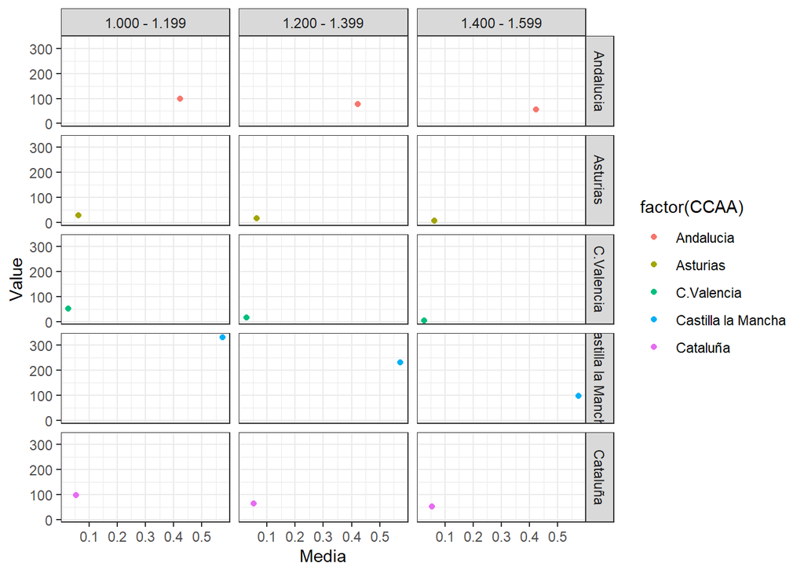

```r
#LA MEDIA SE DESPLAZA MAS A LA DERECHA CUANTO MAS ARRIBA ESTA
grafico<-ggplot(data = tabla, aes(x = media, y = value)) +
  geom_point(aes(colour = factor(CCAA))) +
  facet_grid(CCAA ~ name) +
  labs(x="Media", y="Value") +
  theme_bw()
grafico
```

```r
tumores<-defuncion_poblacion %>%
  rename("Total" = ...2,"<10000" = ...3,"10000-20000" = ...4, "20000-50000" = ...5,"50000-100000" = ...6, "<100000" = ...7, "Capital" = ...8 ) %>%
  slice(55:58) %>%
  select('Defunciones según causa de muerte. Avance enero-mayo 2020':Capital)

tumores
```

```
## # A tibble: 4 × 8
##   Defunciones según causa de muerte…¹ Total `<10000` `10000-20000` `20000-50000`
##   <chr>                               <chr> <chr>    <chr>         <chr>
## 1 "009-041 II.Tumores"                <NA>  <NA>     <NA>          <NA>
## 2 "    Total"                         99,5… 58,835   60,366        81,249
## 3 "    Hombres"                       121,… 70,507   71,154        100,094
## 4 "    Mujeres"                       78,2… 46,796   49,706        62,719
## # ℹ abbreviated name:
## #   ¹`Defunciones según causa de muerte. Avance enero-mayo 2020`
## # ℹ 3 more variables: `50000-100000` <chr>, `<100000` <chr>, Capital <chr>
```

# Relacion de habitantes, fumadores y calidad del aire

En este apartado nos centramos en la media de habitantes fumadores que hay por comunidad autonoma para posteriormente estudiar la relacion entre los fumadores que hay de media y la calidad del aire en las comunidades seleccionadas de manera que resulte un grafico representativo

```r
habitantes_refinado <- habitantes %>%
  filter(Periodo == "1/1/2020") %>%
  select('Comunidades y Ciudades Autónomas', Total, Periodo) %>%
   distinct(`Comunidades y Ciudades Autónomas`, .keep_all = TRUE)%>%
    na.exclude()


habitantes_refinado$Total <- gsub("\\.", "", habitantes_refinado$Total)
habitantes_refinado$Total <- as.numeric(habitantes_refinado$Total)
habitantes_refinado
```

```
## # A tibble: 19 × 3
##    `Comunidades y Ciudades Autónomas`   Total Periodo
##    <chr>                                <dbl> <chr>
##  1 Andalucía                          8464411 1/1/2020
##  2 Aragón                             1329391 1/1/2020
##  3 Asturias, Principado de            1018784 1/1/2020
##  4 Balears, Illes                     1171543 1/1/2020
##  5 Canarias                           2175952 1/1/2020
##  6 Cantabria                           582905 1/1/2020
##  7 Castilla y León                    2394918 1/1/2020
##  8 Castilla - La Mancha               2045221 1/1/2020
##  9 Cataluña                           7780479 1/1/2020
## 10 Comunitat Valenciana               5057353 1/1/2020
## 11 Extremadura                        1063987 1/1/2020
## 12 Galicia                            2701819 1/1/2020
## 13 Madrid, Comunidad de               6779888 1/1/2020
## 14 Murcia, Región de                  1511251 1/1/2020
## 15 Navarra, Comunidad Foral de         661197 1/1/2020
## 16 País Vasco                         2220504 1/1/2020
## 17 Rioja, La                           319914 1/1/2020
## 18 Ceuta                                84202 1/1/2020
## 19 Melilla                              87076 1/1/2020
```

```r
habitantes_refinado <- habitantes_refinado %>%
  mutate(
    CCAA = case_when(
      habitantes_refinado$`Comunidades y Ciudades Autónomas` == "Andalucía" ~ "Andalucia",
      habitantes_refinado$`Comunidades y Ciudades Autónomas` == "Aragón" ~ "Aragon",
      habitantes_refinado$`Comunidades y Ciudades Autónomas` == "Canarias" ~ "Canarias",
      habitantes_refinado$`Comunidades y Ciudades Autónomas` == "Cantabria" ~ "Cantabria",
      habitantes_refinado$`Comunidades y Ciudades Autónomas` == "Castilla - La Mancha" ~ "Castilla la Mancha",
      habitantes_refinado$`Comunidades y Ciudades Autónomas` == "Castilla y León" ~ "CyL",
      habitantes_refinado$`Comunidades y Ciudades Autónomas` == "Cataluña" ~ "Cataluña",
      habitantes_refinado$`Comunidades y Ciudades Autónomas` == "Madrid, Comunidad de" ~ "Madrid",
      habitantes_refinado$`Comunidades y Ciudades Autónomas` == "Navarra, Comunidad Foral de" ~ "Navarra",
      habitantes_refinado$`Comunidades y Ciudades Autónomas` == "Comunitat Valenciana" ~ "C.Valencia",
      habitantes_refinado$`Comunidades y Ciudades Autónomas` == "Extremadura" ~ "Extremadura",
      habitantes_refinado$`Comunidades y Ciudades Autónomas` == "Galicia" ~ "Galicia",
      habitantes_refinado$`Comunidades y Ciudades Autónomas` == "Balears, Illes" ~ "Baleares",
      habitantes_refinado$`Comunidades y Ciudades Autónomas` == "Rioja, La" ~ "La Rioja",
      habitantes_refinado$`Comunidades y Ciudades Autónomas` == "País Vasco" ~ "País Vasco",
      habitantes_refinado$`Comunidades y Ciudades Autónomas` == "Asturias, Principado de" ~ "Asturias",
      habitantes_refinado$`Comunidades y Ciudades Autónomas` == "Murcia, Región de" ~ "Murcia"
    ))%>%
select('CCAA',Total,Periodo)%>%
  na.exclude()
habitantes_refinado
```

```
## # A tibble: 17 × 3
##    CCAA                 Total Periodo
##    <chr>                <dbl> <chr>
##  1 Andalucia          8464411 1/1/2020
##  2 Aragon             1329391 1/1/2020
##  3 Asturias           1018784 1/1/2020
##  4 Baleares           1171543 1/1/2020
##  5 Canarias           2175952 1/1/2020
##  6 Cantabria           582905 1/1/2020
##  7 CyL                2394918 1/1/2020
##  8 Castilla la Mancha 2045221 1/1/2020
##  9 Cataluña           7780479 1/1/2020
## 10 C.Valencia         5057353 1/1/2020
## 11 Extremadura        1063987 1/1/2020
## 12 Galicia            2701819 1/1/2020
## 13 Madrid             6779888 1/1/2020
## 14 Murcia             1511251 1/1/2020
## 15 Navarra             661197 1/1/2020
## 16 País Vasco         2220504 1/1/2020
## 17 La Rioja            319914 1/1/2020
```

```r
fumadores$Total <-gsub(",", ".", fumadores$Total)
fumadores$Total <- as.numeric(fumadores$Total)

fumadores_habitantes <- full_join(x = fumadores,
                              y = habitantes_refinado,
                              by = "CCAA")%>%
  filter(`Consumo de tabaco` == "Fumador diario")%>%
  distinct(`Total.x`,`Total.y`, .keep_all = TRUE)%>%
  slice(1:16)%>%
  mutate(Hab_Fum = (`Total.x` * `Total.y`)/100)%>%
  select(`CCAA`,`Hab_Fum`)

fumadores_habitantes
```

```
## # A tibble: 16 × 2
##    CCAA         Hab_Fum
##    <chr>          <dbl>
##  1 Andalucia   1771601.
##  2 Aragon       236100.
##  3 Asturias     196014.
##  4 Baleares     240635.
##  5 Canarias     450204.
##  6 Cantabria    110052.
##  7 CyL          454555.
##  8 Cataluña    1626898.
##  9 C.Valencia  1005402.
## 10 Extremadura  269402.
## 11 Galicia      478492.
## 12 Madrid      1202752.
## 13 Murcia       357411.
## 14 Navarra      120139.
## 15 País Vasco   357279.
## 16 La Rioja      59952.
```

```r
fumadores_aire <- full_join(x= fumadores_habitantes,
                            y = aire_media_comunidad,
                            by = c("CCAA" )
                            )%>%
  na.exclude()
fumadores_aire
```

```
## # A tibble: 4 × 3
##   CCAA        Hab_Fum  media
##   <chr>         <dbl>  <dbl>
## 1 Andalucia  1771601. 0.422
## 2 Asturias    196014. 0.063
## 3 Cataluña   1626898. 0.054
## 4 C.Valencia 1005402. 0.0275
```

```r
fumadores_habitantes
```

```
## # A tibble: 16 × 2
##    CCAA         Hab_Fum
##    <chr>          <dbl>
##  1 Andalucia   1771601.
##  2 Aragon       236100.
##  3 Asturias     196014.
##  4 Baleares     240635.
##  5 Canarias     450204.
##  6 Cantabria    110052.
##  7 CyL          454555.
##  8 Cataluña    1626898.
##  9 C.Valencia  1005402.
## 10 Extremadura  269402.
## 11 Galicia      478492.
## 12 Madrid      1202752.
## 13 Murcia       357411.
## 14 Navarra      120139.
## 15 País Vasco   357279.
## 16 La Rioja      59952.
```

```r
aire_media_comunidad
```

```
## # A tibble: 7 × 2
##   CCAA                media
##   <chr>               <dbl>
## 1 Andalucia          0.422
## 2 Aragón             0.19
## 3 Asturias           0.063
## 4 C.Valencia         0.0275
## 5 Castilla la Mancha 0.573
## 6 Castilla y León    0.489
## 7 Cataluña           0.054
```

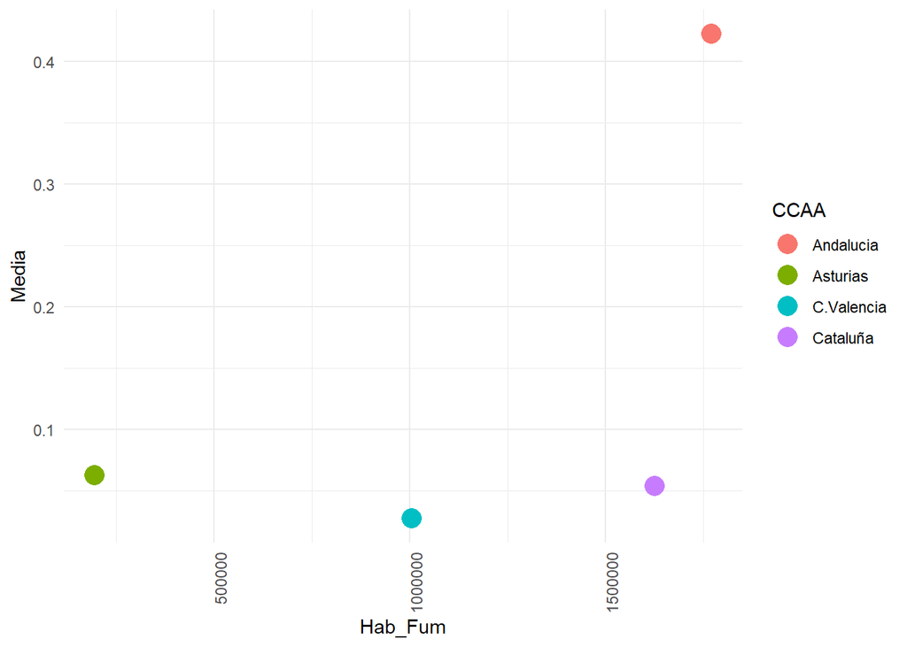

```r
options(repr.plot.width=10, repr.plot.height=8)

ggplot(fumadores_aire, aes(x = Hab_Fum, y = media, color = CCAA)) +
  geom_point(size = 5) +  # Ajusta el tamaño de los puntos
  labs(x = "Hab_Fum", y = "Media") +
  theme_minimal() +
  theme(axis.text.x = element_text(angle = 90, hjust = 1))
```

```r
cancer_nuevo
```

```
## # A tibble: 33 × 4
##    Año   Periodo Parámetro            Cáncer
##    <chr> <chr>   <chr>                 <dbl>
##  1 2022  Año     Andalucía             48.4
##  2 2022  Año     Aragón                 8.76
##  3 2022  Año     Asturias               7.69
##  4 2022  Año     Canarias              12.3
##  5 2022  Año     Cantabria              3.99
##  6 2022  Año     Castilla y León       18.0
##  7 2022  Año     Castilla-La Mancha    12.5
##  8 2022  Año     Cataluña              45.8
##  9 2022  Año     Ceuta                372
## 10 2022  Año     Comunidad Valenciana  31.1
## # ℹ 23 more rows
```

```r
cancer_nuevo$Cáncer <-gsub("\\.", "", cancer_nuevo$Cáncer)
cancer_nuevo$Cáncer <-as.numeric(cancer_nuevo$Cáncer)
#cancer_nuevo$Cáncer <- as.numeric(cancer_nuevo$Cáncer)
cancer_nuevo
```

```
## # A tibble: 33 × 4
##    Año   Periodo Parámetro            Cáncer
##    <chr> <chr>   <chr>                 <dbl>
##  1 2022  Año     Andalucía             48436
##  2 2022  Año     Aragón                 8757
##  3 2022  Año     Asturias               7688
##  4 2022  Año     Canarias               1233
##  5 2022  Año     Cantabria              3986
##  6 2022  Año     Castilla y León       18049
##  7 2022  Año     Castilla-La Mancha    12492
##  8 2022  Año     Cataluña              45836
##  9 2022  Año     Ceuta                   372
## 10 2022  Año     Comunidad Valenciana  31112
## # ℹ 23 more rows
```

```r
cancer_año <- cancer_nuevo %>%
  select(Parámetro, Cáncer) %>%
  rename(
    CCAA = Parámetro,
    Tasa = Cáncer
  )

relacion_cancer_fum <- full_join(cancer_año,fumadores_habitantes) %>%
  filter(CCAA != "Canarias")%>%
  na.exclude()
relacion_cancer_fum
```

```
## # A tibble: 10 × 3
##    CCAA         Tasa  Hab_Fum
##    <chr>       <dbl>    <dbl>
##  1 Asturias     7688  196014.
##  2 Cantabria    3986  110052.
##  3 Cataluña    45836 1626898.
##  4 Extremadura  6952  269402.
##  5 Galicia     19932  478492.
##  6 La Rioja     2083   59952.
##  7 Madrid      38348 1202752.
##  8 Murcia       8073  357411.
##  9 Navarra      4099  120139.
## 10 País Vasco  15003  357279.
```

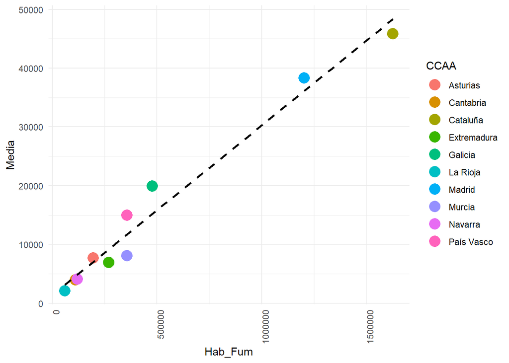

```r
options(repr.plot.width=10, repr.plot.height=8)

ggplot(relacion_cancer_fum, aes(x = Hab_Fum, y = Tasa, color = CCAA)) +
  geom_point(size = 5) +  # Ajusta el tamaño de los puntos
  geom_smooth(method = "lm", se = FALSE, color = "black", linetype = "dashed") +  # Añade una línea de tendencia
  labs(x = "Hab_Fum", y = "Media") +
  theme_minimal() +
  theme(axis.text.x = element_text(angle = 90, hjust = 1))
```

# Relacion entre cancer y calidad forestal

Este análisis representa un primer paso hacia la comprensión de cómo la cantidad de árboles puede influir en la salud humana. Sin embargo, es importante recordar que la correlación no implica causalidad, y se necesitarían más investigaciones para determinar si existe una relación causal entre la cantidad de árboles y la proporción de cáncer.

```r
#colnames(arboles_uso)
#arboles_uso
#cancer_año
#habitantes_refinado
#cancer_proporcion<-full_join(cancer_año, habitantes_refinado, by = "CCAA") %>%
 # select("CCAA","Tasa","Total")%>%
 # na.exclude()%>%
  #mutate(proporcion_cancer = (`Tasa` / `Total`)*100)
#cancer_proporcion

#rel_cancer_arboles<-full_join(arboles_uso,cancer_proporcion, by = c("CCAA")) %>%
 # pivot_longer(cols = c(1.000 - 1.199,1.200 - 1.399,1.400 - 1.599)) %>%
  #filter(!(CCAA %in% "Canarias"))%>%
  #select("CCAA","name","value","proporcion_cancer")%>%
  #rename(Tramo = name,
   #      Arboles = value)%>%
  #na.exclude()

#rel_cancer_arboles
#rel_cancer_arboles_plotted <- ggplot(data = rel_cancer_arboles, aes(x = proporcion_cancer, y = Arboles)) +
#  geom_point(aes(colour = factor(CCAA))) +
#  facet_wrap(~ CCAA) +
#  labs(x="proporcion_cancer", y="Arboles") +
#  theme_bw()


#rel_cancer_arboles_plotted
```

# Relacion entre particulas nocivas y cancer

Este análisis representa un primer paso hacia la comprensión de cómo la calidad del aire puede influir en la salud humana. Sin embargo, es importante recordar que la correlación no implica causalidad, y se necesitarían más investigaciones para determinar si existe una relación causal entre las partículas nocivas en el aire y la proporción de cáncer.

```r
#aire_media_comunidad
#cancer_proporcion
#aireespaña_mod
#rel_aire_cancer_part1 <- full_join(aireespaña_mod,cancer_proporcion, by = "CCAA")%>%
  #select("CCAA","Total.x","proporcion_cancer")%>%
  #na.exclude()

#rel_aire_cancer_part2 <- full_join(aireespaña_mod2,cancer_proporcion, by = "CCAA")%>%
 # select("CCAA","Total.x","proporcion_cancer")%>%
  #na.exclude()


#aireespaña_mod
#aireespaña_mod2




#g1 <- ggplot(rel_aire_cancer_part1, aes(x = Total.x, y = proporcion_cancer, color = CCAA)) +
 # geom_point(size = 5) +
  #geom_smooth(method = "lm", se = FALSE, color = "black", linetype = "dashed") +
  #labs(x = "Particulas Nocivas", y = "Prop. Cancer") +
  #theme_minimal() +
  #theme(axis.text.x = element_text(angle = 90, hjust = 1))

#g2 <- ggplot(rel_aire_cancer_part2, aes(x = Total.x, y = proporcion_cancer, color = CCAA)) +
#  geom_point(size = 5) +
 # geom_smooth(method = "lm", se = FALSE, color = "black", linetype = "dashed") +
  #labs(x = "Particulas Nocivas", y = "Prop. Cancer") +
  #theme_minimal() +
  #theme(axis.text.x = element_text(angle = 90, hjust = 1))

# Combina los gráficos
#grid.arrange(g1, g2, ncol = 1)
```

[output not shown]